# Atividade Prática 2 — Respostas

Econometria Aplicada à Finanças  
Mestrado Profissional em Administração

Autor

Jonathan Vargas Silva

Data de Publicação

17 de agosto de 2026

## Questão 1

**a.**

O viesado para significa que o valor esperado do estimador não é igual ao valor verdadeiro do parâmetro.

**b.**

**c.**

Nos importamos com o viés porque queremos que o estimador, em média, acerte o valor verdadeiro do parâmetro. Um estimador viesado erra sempre na mesma direção (pra mais ou pra menos).

**d.**

Os estimadores B e C são não viesados.

**e.**

O estimador A é o que possui menor variância.

**f.**

O estimador B é o melhor estimador não viesado e com menor variância.

**g.**

Erro padrão é uma medida de quanto o valor do estimador varia de uma amostra para outra. Quanto menor o erro padrão, mais precisa é a estimativa.

**h.**

Verdadeiro. A ausência de viés pode ser avaliada em qualquer tamanho de amostra, mesmo pequena. Já a consistência só faz sentido quando se observa o estimador, a medida que a amostra cresce até o infinito.

## Questão 2

**a.**

```r
# Inspeciona os dados e calcule as informações solicitadas.
glimpse(life_df)
```

```
Rows: 3,106
Columns: 18
$ county_name       <chr> "Autauga", "Autauga", "Baldwin", "Baldwin", "Barbour…
$ county_code       <dbl> 1001, 1001, 1003, 1003, 1005, 1005, 1009, 1009, 1015…
$ state_abb         <chr> "AL", "AL", "AL", "AL", "AL", "AL", "AL", "AL", "AL"…
$ income_quartile   <dbl> 1, 4, 1, 4, 1, 4, 1, 4, 1, 4, 1, 4, 1, 4, 1, 4, 1, 4…
$ life_exp          <dbl> 76.360, 84.215, 79.535, 86.270, 79.733, 86.653, 78.5…
$ pct_uninsured     <dbl> 0.13601, 0.13601, 0.19085, 0.19085, 0.18514, 0.18514…
$ poverty_rate      <dbl> 0.10923, 0.10923, 0.10147, 0.10147, 0.26800, 0.26800…
$ pct_religious     <dbl> 0.56113, 0.56113, 0.47243, 0.47243, 0.41170, 0.41170…
$ pct_black         <dbl> 0.1700900, 0.1700900, 0.1022469, 0.1022469, 0.460396…
$ pct_hispanic      <dbl> 0.0139681, 0.0139681, 0.0175622, 0.0175622, 0.016461…
$ unemployment_rate <dbl> 0.037379, 0.037379, 0.039112, 0.039112, 0.068132, 0.…
$ median_hh_inc     <dbl> 34.380, 34.380, 39.220, 39.220, 24.274, 24.274, 30.2…
$ is_urban          <dbl> 1, 1, 1, 1, 0, 0, 1, 1, 1, 1, 1, 1, 1, 1, 1, 1, 1, 1…
$ pop               <dbl> 43671, 43671, 140415, 140415, 29038, 29038, 51024, 5…
$ pop_density       <dbl> 73.277, 73.277, 87.960, 87.960, 32.815, 32.815, 79.0…
$ pct_smoke         <dbl> 0.333333, 0.133333, 0.268097, 0.176991, 0.228571, 0.…
$ pct_obese         <dbl> 0.37500, 0.13333, 0.29805, 0.13575, 0.29412, 0.27778…
$ pct_exercise      <dbl> 0.50000, 0.80000, 0.59943, 0.83796, 0.54286, 0.72222…
```

```r
# Número de observações
nrow(life_df)
```

```
[1] 3106
```

```r
# Número de variáveis
ncol(life_df)
```

```
[1] 18
```

```r
# Nnúmero de observações completas
sum(complete.cases(life_df))
```

```
[1] 3106
```

```r
# Número de condados distintos
n_distinct(life_df$county_name)
```

```
[1] 1051
```

```r
# Número de estados distintos
n_distinct(life_df$state.abb)
```

```
[1] 0
```

```r
# Número de observações em cada quartil de renda
count(life_df, income_quartile)
```

```
# A tibble: 2 × 2
  income_quartile     n
            <dbl> <int>
1               1  1553
2               4  1553
```

```r
# Número de valores ausentes em cada variável
colSums(is.na(life_df))
```

```
      county_name       county_code         state_abb   income_quartile
                0                 0                 0                 0
         life_exp     pct_uninsured      poverty_rate     pct_religious
                0                 0                 0                 0
        pct_black      pct_hispanic unemployment_rate     median_hh_inc
                0                 0                 0                 0
         is_urban               pop       pop_density         pct_smoke
                0                 0                 0                 0
        pct_obese      pct_exercise
                0                 0
```

**b.**

```r
# Cria a variável high_income.
life_df <- life_df |>
  mutate(high_income = if_else(income_quartile == 4, 1, 0))
```

**c.**

```r
# Calcula as estatísticas descritivas por quartil de renda.
tabela_resultados <- tibble(life_df) |>
  group_by(income_quartile) |>
  summarise(
    life_exp_medio = mean(life_exp),
    life_exp_sd = sd(life_exp),
    pct_smoke_medio = mean(pct_smoke),
    pct_smoke_sd = sd(pct_smoke),
    pct_obese_medio = mean(pct_obese),
    pct_obese_sd = sd(pct_obese),
    pct_exercise_medio = mean(pct_exercise),
    pct_exercise_sd = sd(pct_exercise)
  )

glimpse(tabela_resultados)
```

```
Rows: 2
Columns: 9
$ income_quartile    <dbl> 1, 4
$ life_exp_medio     <dbl> 78.867, 85.975
$ life_exp_sd        <dbl> 1.4519, 1.3667
$ pct_smoke_medio    <dbl> 0.28063, 0.12982
$ pct_smoke_sd       <dbl> 0.079562, 0.079082
$ pct_obese_medio    <dbl> 0.30830, 0.23308
$ pct_obese_sd       <dbl> 0.089119, 0.097906
$ pct_exercise_medio <dbl> 0.59716, 0.85064
$ pct_exercise_sd    <dbl> 0.094268, 0.088506
```

Em todas as variáveis observadas, é possível constatar que, em média, o grupo de maior renda possui os melhores indicadores médios.

**d.**

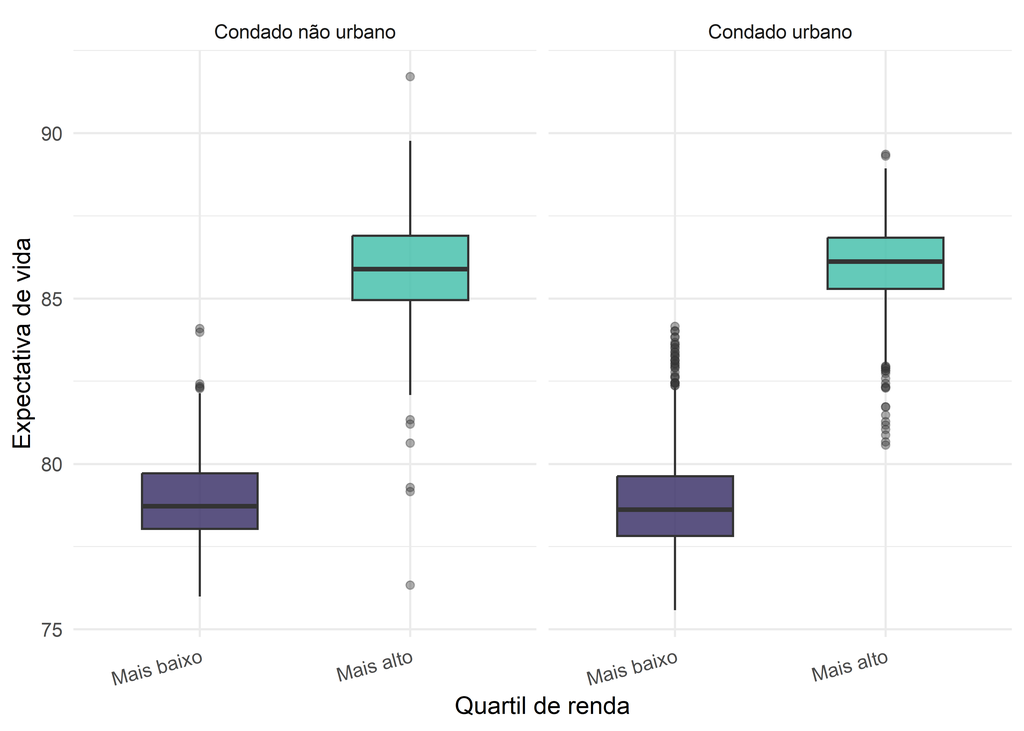

Boxplots da expectativa de vida por grupo de renda e condição urbana.

**e.**

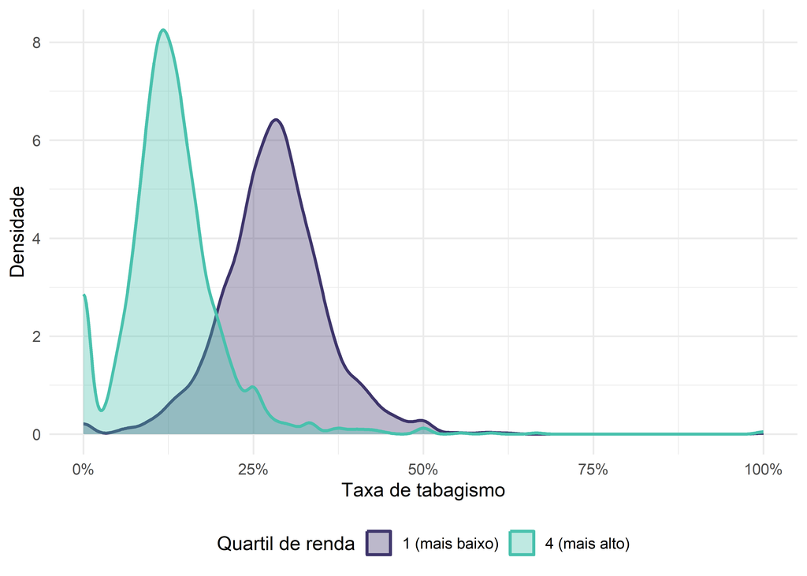

Gráfico de densidade das taxas de tabagismo por grupo de renda.

**f.**

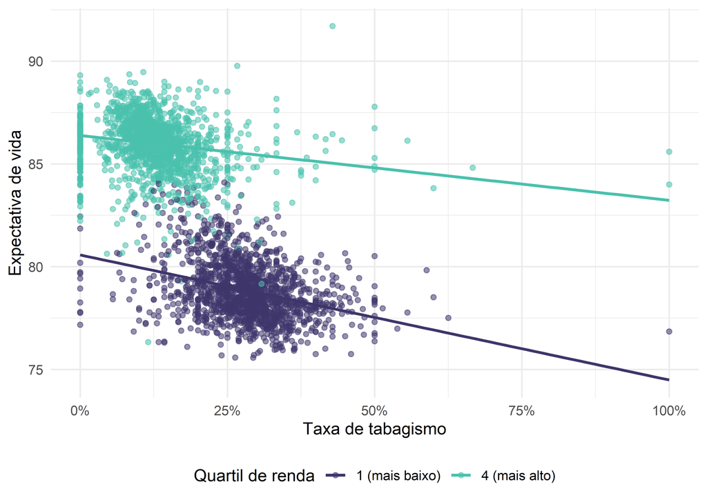

Gráfico de dispersão entre expectativa de vida e taxa de tabagismo.

**g.**

Os gráficos das questões D, E e F sugerem que a renda está associada positivamente à expectativa de vida e negativamente à taxa de tabagismo. Quanto maior a renda, maior a expectativa de vida e menor o tabagismo. Além disso, dentro de cada grupo de renda, quanto maior o tabagismo, menor a expectativa de vida.

**h.**

O gráfico da questão F sugere que o viés de variável omitida pode ser uma preocupação porque a renda está relacionada tanto com o tabagismo quanto com a expectativa de vida. Portanto, se essa variável for deixada de fora do modelo, o resultado pode ser inconsistente.

**i.**

Espera-se que a omissão do grupo de renda produza um viés para baixo na estimativa de MQO de _1. Visto que ao omitir a renda, o coeficiente do tabagismo tende a ficar mais negativo do que realmente é.

**j.**

```r
# 1. Estima os modelos simples e com controle para alta renda.
modelo_simples <- lm(life_exp ~ pct_smoke, data = life_df)
modelo_alta_renda <- lm(life_exp ~ pct_smoke + high_income, data = life_df)

# Organiza os resultados em uma tabela.
tabela_modelo <- bind_rows(
  simples = broom::tidy(modelo_simples),
  alta_renda = broom::tidy(modelo_alta_renda),
  .id = "modelo"
)
knitr::kable(tabela_modelo, digits = 3)
```

| modelo | term | estimate | std.error | statistic | p.value |
| --- | --- | --- | --- | --- | --- |
| simples | (Intercept) | 87.512 | 0.103 | 852.097 | 0 |
| simples | pct_smoke | -24.808 | 0.442 | -56.180 | 0 |
| alta_renda | (Intercept) | 80.164 | 0.093 | 860.963 | 0 |
| alta_renda | pct_smoke | -4.623 | 0.308 | -15.006 | 0 |
| alta_renda | high_income | 6.411 | 0.067 | 95.073 | 0 |

**k.**

Sim, a mudança observada na questão J é consistente com a previsão da questão I. Visto que um aumento de 10 pontos percentuais na taxa de tabagismo está associado a uma queda de cerca de 2,48 anos na expectativa de vida no modelo simples, mas de apenas 0,46 anos no modelo que controla a renda

**l.**

```r
# Estima um modelo que também controla para a condição urbana.
modelo_condado_urbano <- lm(life_exp ~ pct_smoke + high_income + is_urban, data = life_df)
broom::tidy(modelo_condado_urbano)
```

```
# A tibble: 4 × 5
  term        estimate std.error statistic  p.value
  <chr>          <dbl>     <dbl>     <dbl>    <dbl>
1 (Intercept)  80.1       0.105    762.    0
2 pct_smoke    -4.62      0.308    -15.0   3.41e-49
3 high_income   6.41      0.0674    95.1   0
4 is_urban      0.0537    0.0611     0.879 3.79e- 1
```

Não, a inclusão do indicador de condado urbano não altera de forma relevante a estimativa do coeficiente associado ao tabagismo. Isso indica que, diferente da renda, a condição urbana não é uma variável importante para explicar a relação entre tabagismo e expectativa de vida nesse modelo.